library(markdown)

### Tutorial 3 Part 2 (To be submitted)

- Dataset required: `ds_salaries.csv`

The dataset contains Data Science jobs salary data aggregated by ai-jobs.net. There are 607 observations and 11 variables. Each of the variable (column) is defined as follows:

- `work_year`: The year the salary was paid.
- `experience_level`: The experience level in the job during the year with the following possible values: EN Entry-level / Junior; MI Mid-level / Intermediate; SE Senior-level / Expert; EX Executive-level / Director
- `employment_type`: The type of employment for the role: PT Part-time; FT Full-time; CT Contract; FL Freelance
- `job_title`: The role worked in during the year.
- `salary`: The total gross salary amount paid.
- `salary_currency`: The currency of the salary paid as an ISO 4217 currency code.
- `salary_in_usd`: The salary in USD (FX rate divided by avgerage USD rate for the respective year via fxdata.foorilla.com).
- `employee_residence`: Employee’s primary country of residence during the work year as an ISO 3166 country code.
- `remote_ratio`: The overall amount of work done remotely, possible values are as follows: 0 No remote work (less than 20%); 50 Partially remote; 100 Fully remote (more than 80%)
- `company_location`: The country of the employer’s main office or contracting branch as an ISO 3166 country code.
- `company_size`: The average number of people that worked for the company during the year: S less than 50 employees (small); M 50 to 250 employees (medium); L more than 250 employees (large)

```r
#install.packages - only need to run this code once to install the package
# load required packages
# library("xxxx")
library(tidyverse) #need to call the library before you use the packages
library(rpivotTable)
library(knitr)
library(readxl)
```

```r
#import dataset into RStudio
DS <- read.csv("~/Downloads/ds_salaries.csv")
```

As a business analytics analyst, you are required to perform the following tasks as described in each question below.

### Q2.(ai) Job Information Dashboard Part 1 (4 marks)

- First, analyse the data to see how many job titles are captured in the dataset? Write you answer below.
- Next, create a table and barplot to visualise the frequency distribution for the top 10 Job titles.

**BEGIN: YOUR ANSWER**

```r
job_number <- DS %>%
  count(job_title)
job_freq <- (job_number %>% arrange(desc(n)))[1:10,]
kable(job_freq,caption="Frequency Distribution of Top 10 Job Titles")
```

Frequency Distribution of Top 10 Job Titles

| job_title | n |
| --- | --- |
| Data Scientist | 143 |
| Data Engineer | 132 |
| Data Analyst | 97 |
| Machine Learning Engineer | 41 |
| Research Scientist | 16 |
| Data Science Manager | 12 |
| Data Architect | 11 |
| Big Data Engineer | 8 |
| Machine Learning Scientist | 8 |
| AI Scientist | 7 |

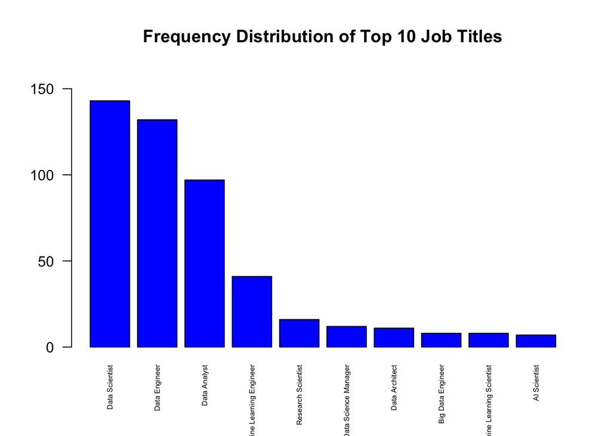

```r
barplot(job_freq$n,main = "Frequency Distribution of Top 10 Job Titles",col="blue", ylim=c(0,160), names.arg= job_freq$job_title, las = 2, cex.names = 0.5)
```

**END: YOUR ANSWER**

### Q2.(aii) Job Information Dashboard Part 2 (6 marks) - Create a table and pie chart for each of the following variables: `employment_type`, `experience_level`, `work_year` (6 marks)

**BEGIN: YOUR ANSWER**

```r
employ_freq <- DS %>% count(employment_type)

kable(employ_freq, caption = "Employment Type")
```

Employment Type

| employment_type | n |
| --- | --- |
| CT | 5 |
| FL | 4 |
| FT | 588 |
| PT | 10 |

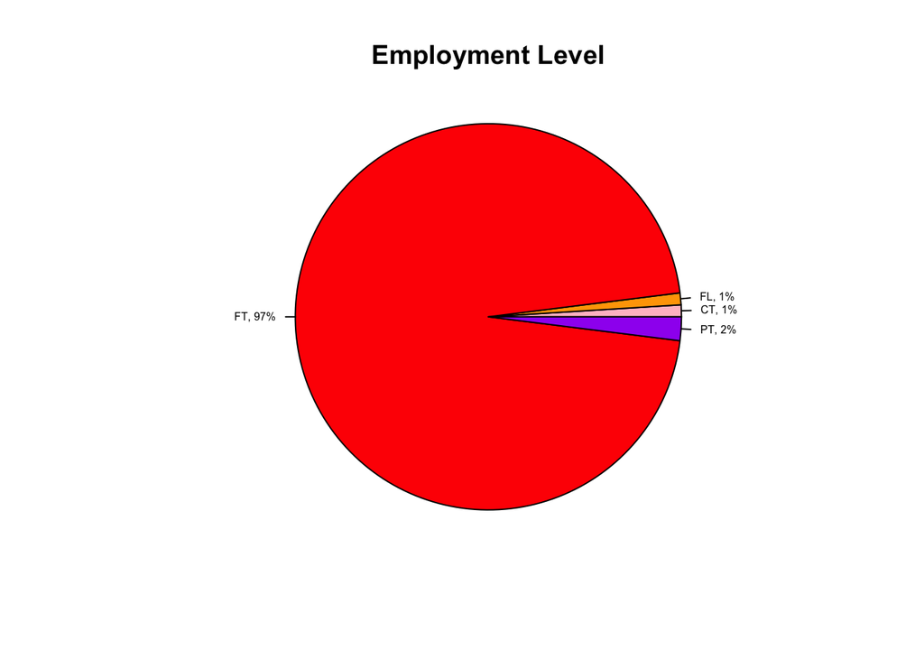

```r
slice.payment <- employ_freq
employment.piepercent <- 100*round(employ_freq$n/sum(employ_freq$n),2)
label <- employ_freq$employment_type
label <- paste(label, ",", sep = "")
label <- paste(label, employment.piepercent)
label <- paste (label, "%", sep="") #understood!
pie(employment.piepercent, labels = label, col=c("pink", "orange", "red", "purple"), radius = 1, main = "Employment Level", cex = 0.5)
```

```r
exp_freq <- DS %>% count(experience_level)

kable(exp_freq, caption = "Experience Level")
```

Experience Level

| experience_level | n |
| --- | --- |
| EN | 88 |
| EX | 26 |
| MI | 213 |
| SE | 280 |

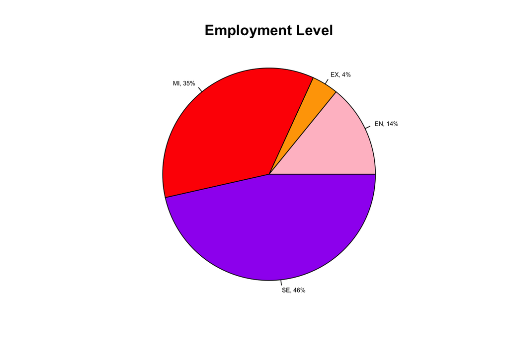

```r
slice.payment <- exp_freq
exp.piepercent <- 100*round(exp_freq$n/sum(exp_freq$n),2)
label <- exp_freq$experience_level
label <- paste(label, ",", sep = "")
label <- paste(label, exp.piepercent)
label <- paste (label, "%", sep="") #understood!
pie(exp.piepercent, labels = label, col=c("pink", "orange", "red", "purple"), radius = 1, main = "Employment Level", cex = 0.5)
```

```r
work_year <- DS %>% count(work_year)

kable(work_year, caption = "Work Year")
```

Work Year

| work_year | n |
| --- | --- |
| 2020 | 72 |
| 2021 | 217 |
| 2022 | 318 |

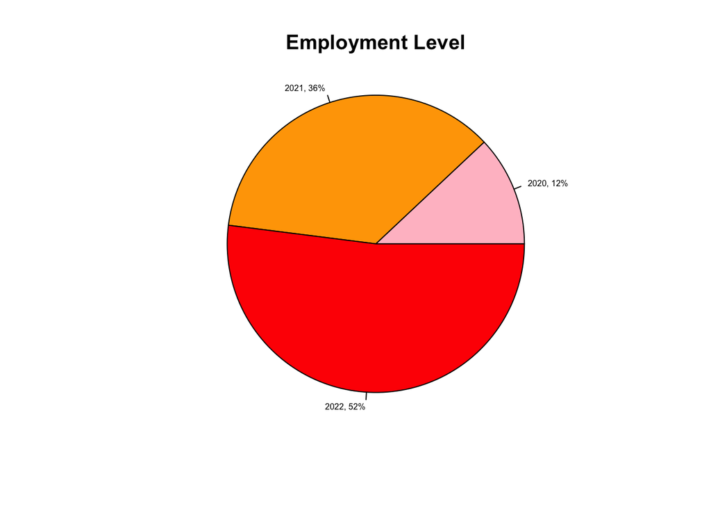

```r
slice.payment <- work_year
workyr.piepercent <- 100*round(work_year$n/sum(work_year$n),2)
label <- work_year$work_year
label <- paste(label, ",", sep = "")
label <- paste(label, workyr.piepercent)
label <- paste (label, "%", sep="") #understood!
pie(workyr.piepercent, labels = label, col=c("pink", "orange", "red", "purple"), radius = 1, main = "Employment Level", cex = 0.5)
```

**END: YOUR ANSWER**

### Q2.(aiii) Job Information Dashboard Part 3 (5 marks) - Create a table and chart to compare the frequency distributions for `employment_type` across the top 3 job titles. - Create a table and chart to compare the frequency distributions for `experience_level` across the top 3 job titles.

- Based on charts in 2aii and 2aiii, describe briefly the type of jobs that are in the dataset. For example, is there more of a particular employment type in the data, and is the pattern the same for the top 3 job titles.
- For tutorial discussion only: What do you think about the job titles captured in the data. Do you think there are any issues with reliability or validity?

  **BEGIN: YOUR ANSWER**

```r
job_top3 <- DS[DS$job_title %in% c("Data Scientist","Data Engineer", "Data Analyst"),]

employ3_freq <- job_top3 %>%
  group_by(job_title,employment_type) %>%
  tally()
employ3_freq.spread <- employ3_freq  %>% spread(key = job_title, value = n)
employ3_freq.spread[is.na(employ3_freq.spread)] <- 0
kable(employ3_freq.spread, caption = "Contingency table for job title and employment type", col.names = c("Employment Type", "Data Analyst","Data Engineer","Data Scientist"))
```

Contingency table for job title and employment type

| Employment Type | Data Analyst | Data Engineer | Data Scientist |
| --- | --- | --- | --- |
| FL | 0 | 1 | 1 |
| FT | 96 | 129 | 140 |
| PT | 1 | 2 | 2 |

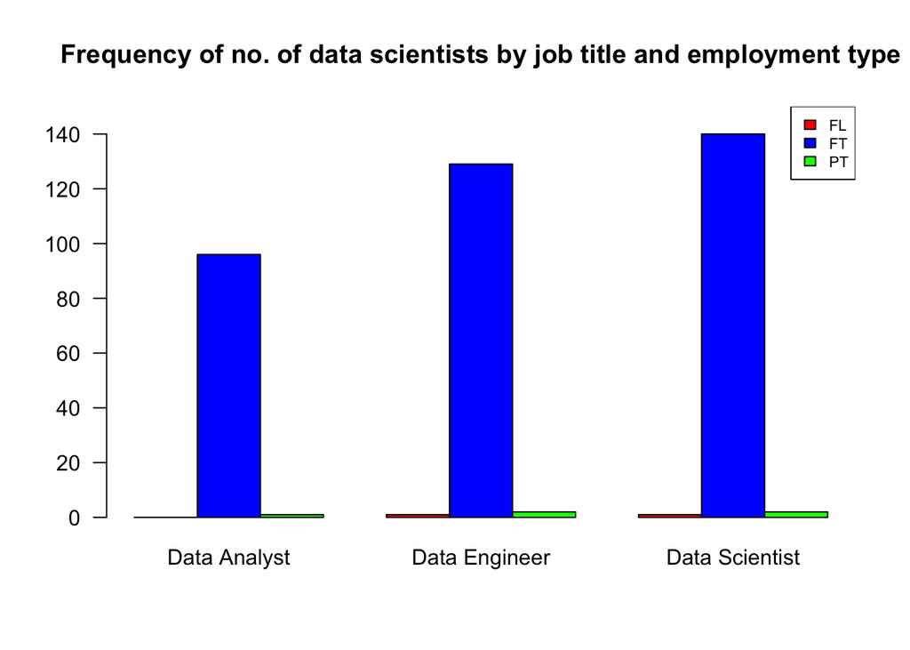

```r
barmatrix.employ3_freq <- as.matrix(employ3_freq.spread[,c(2:4)])
barplot(barmatrix.employ3_freq, col = c("red", "blue", "green"), main = "Frequency of no. of data scientists by job title and employment type", beside = TRUE, ylim = c(0,150), las = 1)
legend("topright", cex = 0.7, fill = c("red", "blue", "green"), legend =employ3_freq.spread$employment_type)
```

```r
exp3_freq <- job_top3 %>%
  group_by(job_title,experience_level) %>%
  tally()
exp3_freq.spread <- exp3_freq  %>% spread(key = job_title, value = n)
exp3_freq.spread[is.na(exp3_freq.spread)] <- 0
kable(exp3_freq.spread, caption = "Contingency table for job title and experience level", col.names = c("Experience Level", "Data Analyst","Data Engineer","Data Scientist"))
```

Contingency table for job title and experience level

| Experience Level | Data Analyst | Data Engineer | Data Scientist |
| --- | --- | --- | --- |
| EN | 12 | 12 | 22 |
| EX | 2 | 4 | 0 |
| MI | 29 | 53 | 60 |
| SE | 54 | 63 | 61 |

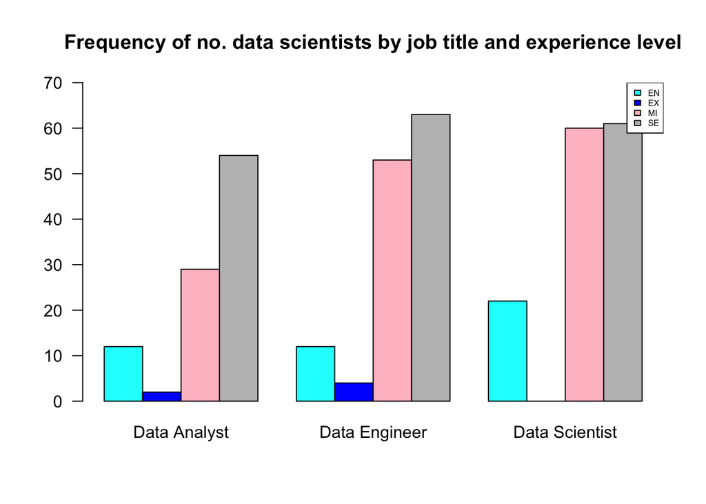

```r
barmatrix.exp3_freq <- as.matrix(exp3_freq.spread[,c(2:4)])
barplot(barmatrix.exp3_freq, col = c("cyan", "blue", "pink", "grey"), main = "Frequency of no. data scientists by job title and experience level", beside = TRUE, ylim = c(0,70), las =1)
legend("topright", cex = 0.5, fill = c("cyan", "blue", "pink", "grey"), legend =exp3_freq.spread$experience_level)
```

```r
# For job title and employment type: the number of data scientists under the employment type FT is significantly more than that of FL and PT across all three job titles; employment type FT is least for data analyst, followed by data engineer and then the most for data scientist; both FL and PT are slightly lower for data analyst and constant for data engineer and scientist (based on table, less obvious from bar graph)

# For job title and experience level: Across all three job titles, SE is the most prominent, followed by MI, EN and then lastly EX; for data scientist, no one has the experience level EX while EX is most prominent amongst data engineers out of the three job titles; there is a significant difference between SE and MI for data analyst which is lesser for data engineer and the least for data scientist
```

**END: YOUR ANSWER**

### Q2.(b) Salary Dashboard (10 marks) This dashboard is to visualise the salary data captured in the dataset better.

- 1. Create a table and chart to visualise the frequency distributions for `salaryinusd`
- 2. Create separate tables and charts to visualise the frequency distributions for `salaryinusd` across the top 3 Job titles. Do you observe any difference across the 3 job titles? [HINT: you may want to use the same breaks/bin width for the 3 charts for ease of comparison]
- For tutorial discussion only: What do the round and square brackets for the intervals in the frequency distribution tables mean?

  **BEGIN: YOUR ANSWER**

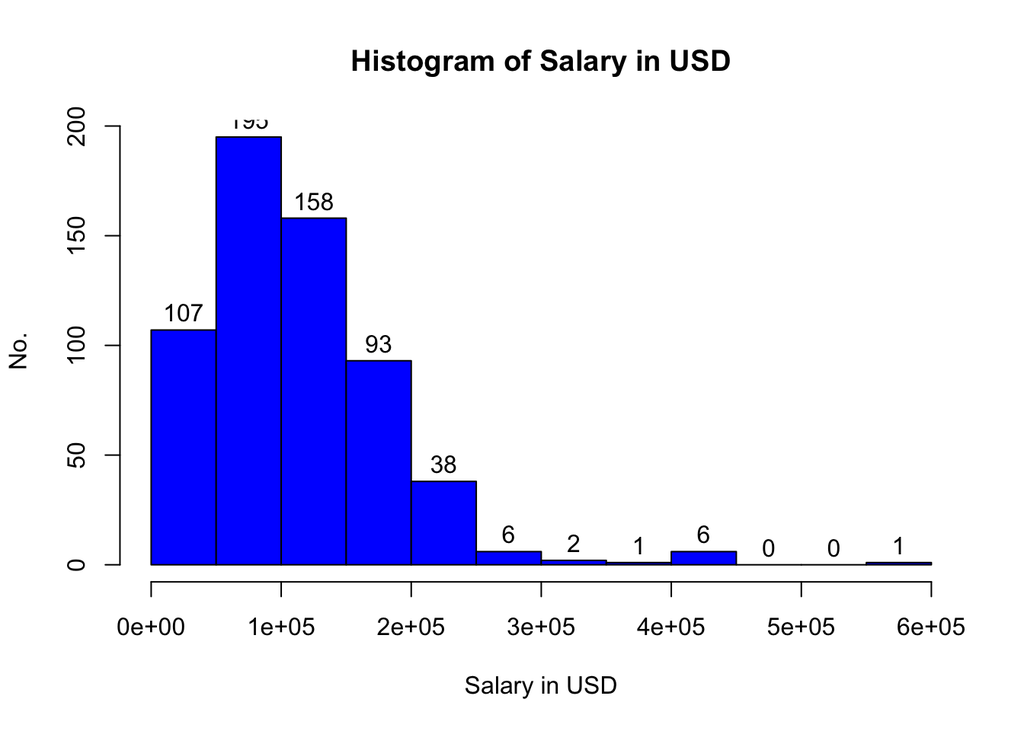

```r
##i

h.salary <- hist(DS$salary_in_usd,
             main = "Histogram of Salary in USD",
             xlab = "Salary in USD",
             ylab = "No.",
             col = "blue",
             labels = TRUE)
```

```r
s.grp <- cut(DS$salary_in_usd,h.salary$breaks)
t.emp <- table(s.grp)
kable(t.emp, caption = "Frequency distribution by Salary in USD")
```

Frequency distribution by Salary in USD

| s.grp | Freq |
| --- | --- |
| (0,5e+04] | 107 |
| (5e+04,1e+05] | 195 |
| (1e+05,1.5e+05] | 158 |
| (1.5e+05,2e+05] | 93 |
| (2e+05,2.5e+05] | 38 |
| (2.5e+05,3e+05] | 6 |
| (3e+05,3.5e+05] | 2 |
| (3.5e+05,4e+05] | 1 |
| (4e+05,4.5e+05] | 6 |
| (4.5e+05,5e+05] | 0 |
| (5e+05,5.5e+05] | 0 |
| (5.5e+05,6e+05] | 1 |

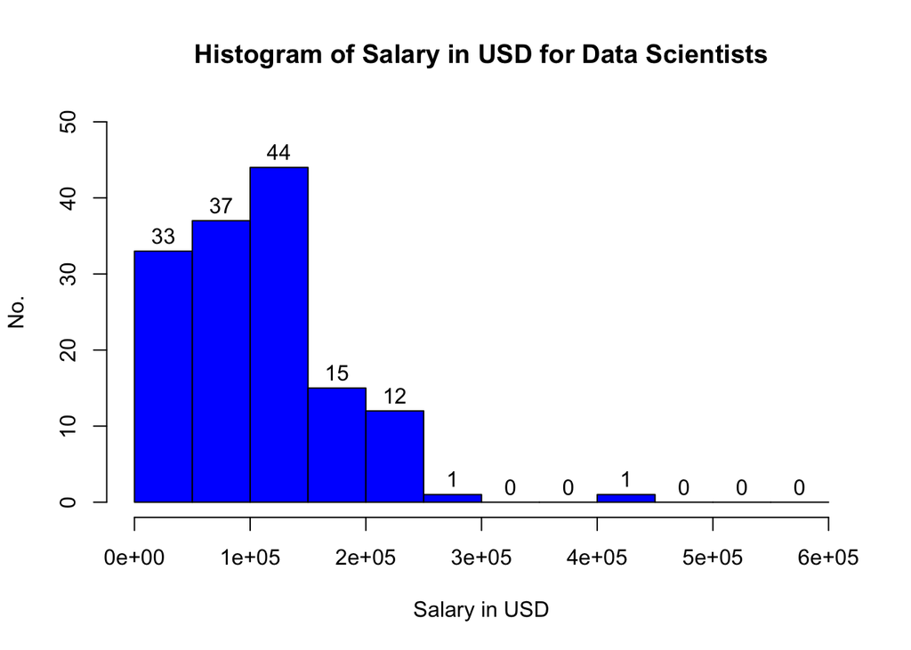

```r
#ii
dsbii <- DS %>% filter(job_title == "Data Scientist")

hist.dsbii <- hist(dsbii$salary_in_usd,
              main = "Histogram of Salary in USD for Data Scientists",
              xlab = "Salary in USD",
              ylab = "No.",
              col=c("blue"),
              ylim=c(0,50),
              xlim = c(0, 600000),
              labels = TRUE,
              breaks  =seq(from=0,to=600000, by=50000))
```

```r
hist.Group <- cut(DS$salary_in_usd, hist.dsbii$breaks, include.lowest = TRUE)
hist.table <- table(hist.Group)
kable(hist.table, caption = "Frequency Distribution by Salary in USD for Data Scientist")
```

[output not shown]

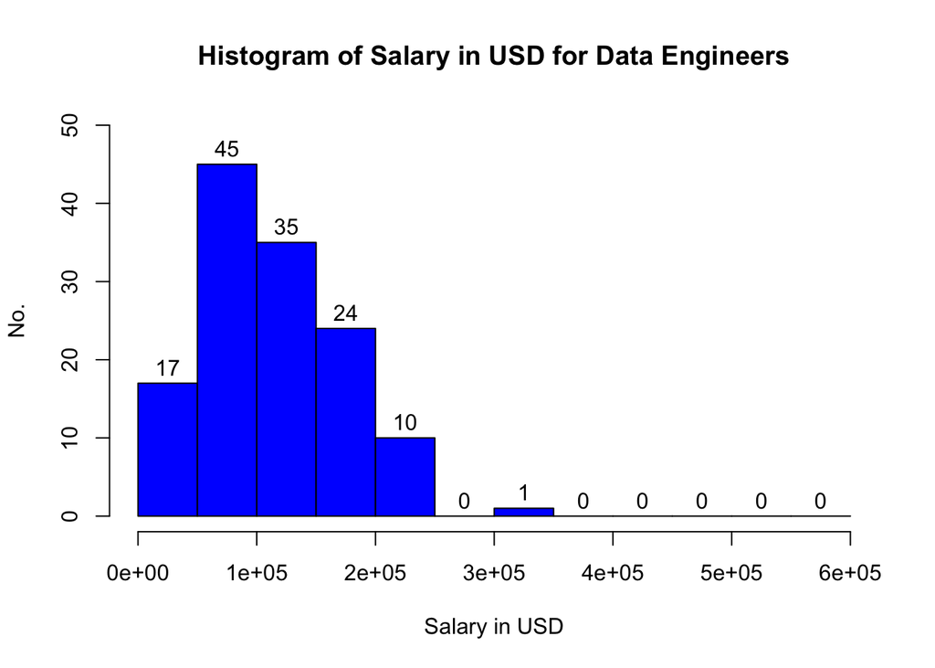

```r
debii <- DS %>% filter(job_title == "Data Engineer")

hist.debii <- hist(debii$salary_in_usd,
              main = "Histogram of Salary in USD for Data Engineers",
              xlab = "Salary in USD",
              ylab = "No.",
              col=c("blue"),
              ylim=c(0,50),
              xlim = c(0, 600000),
              labels = TRUE,
              breaks  =seq(from=0,to=600000, by=50000))
```

```r
hist.Groupde <- cut(DS$salary_in_usd, hist.debii$breaks, include.lowest = TRUE)
hist.tablede <- table(hist.Groupde)
kable(hist.tablede, caption = "Frequency Distribution by Salary in USD for Data Engineers")
```

[output not shown]

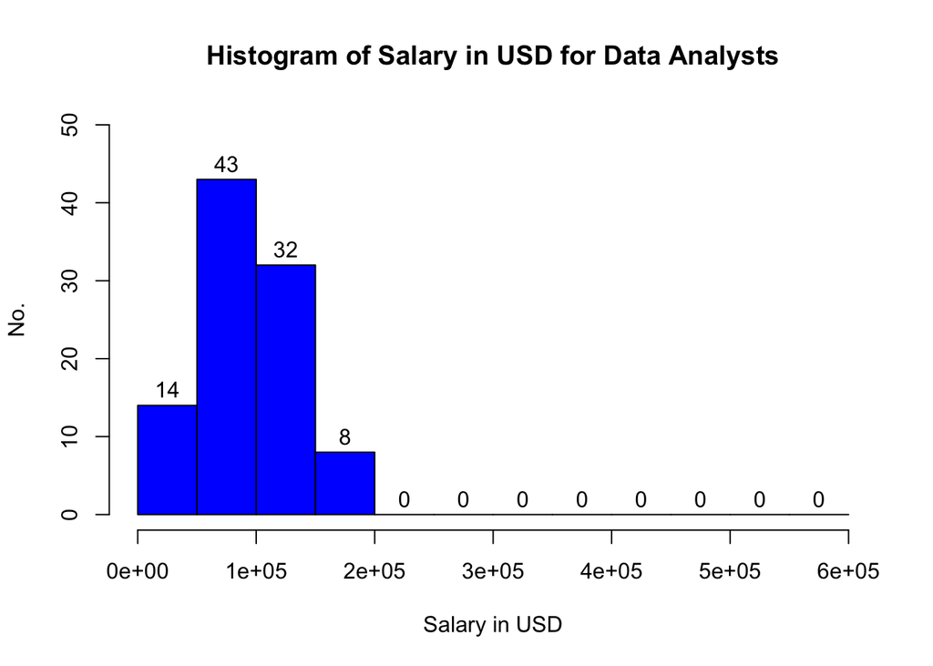

```r
data.dabii <- DS %>% filter(job_title == "Data Analyst")

hist.dabii <- hist(data.dabii$salary_in_usd,
              main = "Histogram of Salary in USD for Data Analysts",
              xlab = "Salary in USD",
              ylab = "No.",
              col=c("blue"),
              ylim=c(0,50),
              xlim = c(0, 600000),
              labels = TRUE,
              breaks  =seq(from=0,to=600000, by=50000))
```

```r
hist.Groupda <- cut(DS$salary_in_usd, hist.dabii$breaks, include.lowest = TRUE)
hist.tableda <- table(hist.Groupda)
kable(hist.tableda, caption = "Frequency Distribution by Salary in USD for Data Analysts")
```

[output not shown]

**END: YOUR ANSWER**

### Q2.(c) Interactive Contingency Table (2 marks) Create a contingency table with the `rPivotTable` function for Data Scientist jobs that displays frequency for the following 3 variables: experience_level, employment_type and work_year.

**BEGIN: YOUR ANSWER**

```r
freq_table <- DS%>%
  filter(job_title == "Data Scientist")
rpivotTable(DS,rows = "work_year", columns = c("experience_level", "employment_type"))
```

[interactive table not shown]

**END: YOUR ANSWER**

### Q2.(d) Pareto Analysis (3 marks) Conduct a Pareto analysis on `salary_in_usd` to be displayed in this dashboard. (Hint: check the number and percentage of individuals that contribute to 80% of the total salary_in_usd earned in the dataset. Do you observe a 80-20 split? If not, what is the ratio?).

For tutorial discussion only: Try different percentages instead of 80 (say 90, 70, 60, etc.). Is there a percentage that gives you a sum of proportions closer to 100%?

**BEGIN: YOUR ANSWER**

```r
salary <- DS %>%
  select(salary_in_usd) %>%
  arrange(desc(salary_in_usd))
salary$Percentage <- salary$salary_in_usd/sum(salary$salary_in_usd)
salary$cumu <- cumsum(salary$Percentage)
salary$cumu.cust <- as.numeric(rownames(DS))/nrow(DS)
which(salary$cumu > 0.8)[1]
```

```
## [1] 352
```

```r
(which(salary$cumu > 0.8)[1])/nrow(DS)
```

```
## [1] 0.5799012
```

```r
#the ratio is 0.5799012
```

**END: YOUR ANSWER**